# Lecture-Lab 6: Extended data collection and analysis

KNHSM08 / KOMP014: Quantitative Methods in  
Music Education Research 2026

nils.holmberg@iko.lu.se

## Lecture-Lab 1

- **Module:** Survey data
- **Topic:** Research design, theoretical models, survey construction, data collection, descriptive analysis
- **Date:** 2026-09-01 at 11—17
- **Place:** MHM
- **Readings:** Muijs (2011), chs. 1 and 3–4; Ehninger et al. (2021)

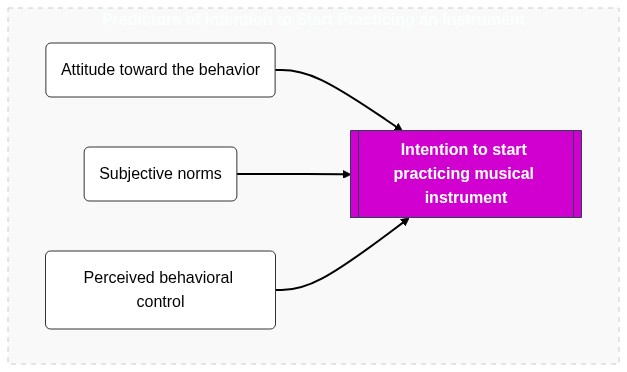

## Lecture-Lab 2 (David Johnson)

- **Module:** Survey data
- **Topic:** Data collection, data analysis, descriptive, univariate, bivariate, frequencies, distributions
- **Date:** 2026-09-04 at 09—12
- **Place:** Zoom
- **Readings:** Muijs (2011), chs. 5–6; Johnson (2021), chs. 1, 4–5

[figure not shown]

## Lecture-Lab 3

- **Module:** Survey data
- **Topic:** Online survey experiments, inferential analysis, hypothesis testing, [Jamovi](https://www.jamovi.org/download.html) software
- **Date:** 2026-09-08 at 11—17
- **Place:** MHM
- **Readings:** Muijs (2011), chs. 2, 7–8; Krupp-Schleußner and Lehmann-Wermser (2018)


## Lecture-Lab 4 (Gary McPherson)

- **Module:** Survey data
- **Topic:** Multivariate analysis, association, correlation, causality, survey data collection and analysis
- **Date:** 2026-09-11 at 09—12
- **Place:** Zoom
- **Readings:** Muijs (2011), chs. 7–10; McPherson and O’Neill (2010b); McPherson and O’Neill (2010a)

[figure not shown]

## Lecture-Lab 5

- **Module:** Extended data
- **Topic:** Attitudes vs. content, quantitative content analysis, natural language processing (NLP), process tracing
- **Date:** 2026-09-15 at 11—17
- **Place:** MHM
- **Readings:** Ehninger et al. (2021); Johnson (2021), ch. 4

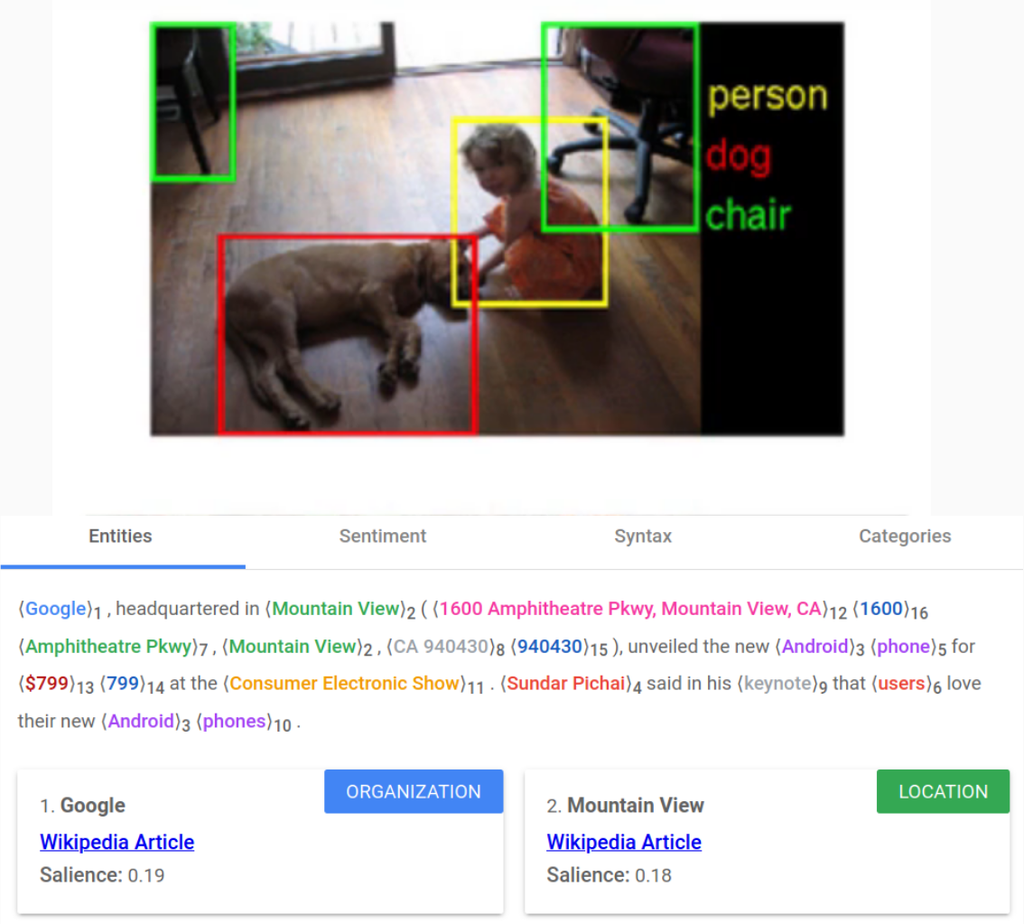

## Individual Work 1

- **Module:** Survey data
- **Topic:** Design and implement a quantitative study (questionnaire or content) using [Google Forms](https://docs.google.com/forms/?authuser=0)
- **Date:** 2026-09-18 at 09—12
- **Place:** Zoom
- **Readings:**

📚 💻  
🧑‍🎓

## Lecture-Lab 6

- **Module:** Extended data
- **Topic:** Multivariate analysis and multiple linear regression (MLR) analysis, using [Google Colab](https://colab.research.google.com/)
- **Date:** 2026-09-22 at 11—17
- **Place:** MHM (or Zoom?)
- **Readings:** Muijs (2011), ch. 9; Djurfeldt and Barmark (2009), chs. 3, 5–6; Björk et al. (2019)

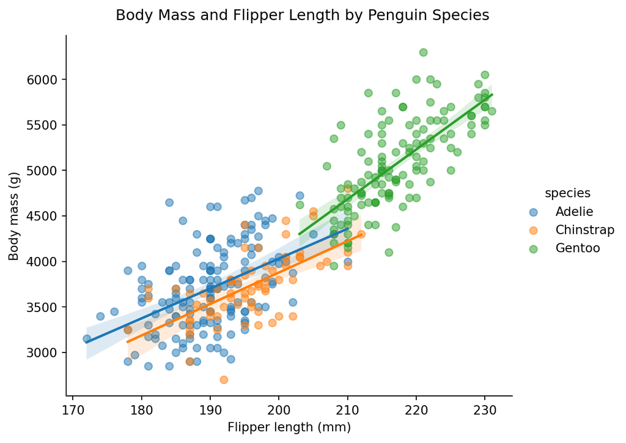

## Lecture-Lab 7

- **Module:** Extended data
- **Topic:** Interactions between variables, data transformations, logistic regression, using [Google Colab](https://colab.research.google.com/)
- **Date:** 2026-09-25 at 09—12
- **Place:** Zoom
- **Readings:** Muijs (2011), ch. 12; Djurfeldt and Barmark (2009), ch. 10

[figure not shown]

## Examination 1

- **Module:** Examination assignment 2
- **Topic:** Organize and present a quantitative study (survey or content) according to IMRD structure
- **Date:** 2026-09-29 at 10—16
- **Place:** MHM
- **Readings:** [Canvas page](https://canvas.education.lu.se/courses/41415/assignments/296106?module_item_id=1839220)

Intro

Methods

Results

Discussion

## Individual Work 2

- **Module:** Extended data
- **Topic:** Structure of journal article introduction, research questions, literature review, theoretical models, testable hypotheses
- **Date:** 2026-10-02 at 09—12
- **Place:** Zoom
- **Readings:**

📚 💻  
🧑‍🎓

## Examination 2

- **Module:** Examination assignment 1
- **Topic:** Literature review paper and opposition, develop Introduction in IMRD structure
- **Date:** 2026-10-20 at 10—16
- **Place:** MHM
- **Readings:** [Canvas page](https://canvas.education.lu.se/courses/41415/assignments/296107?module_item_id=1839222)

Intro

Methods

Results

Discussion

## Open science methods

- **Replicability**: Python enables reproducible research with shareable scripts.
- **Transparency**: Open-source code makes analyses fully visible.
- **Collaboration**: Supports teamwork via GitHub and Jupyter Notebooks.
- **Open Source**: Free and community-driven for open science. 🚀

## AI use in academic work

- OK: brainstorm ideas, do research
- OK: generate project materials
- OK: data analysis, statistics tools
- OK: be transparent with your prompts
- Not OK: copy-paste text to your exam
- Not OK: generate fake empirical data
- Not OK: upload content you dont own
- Not OK: upload data with personal info
- https://gemini.google.com/

## Lecture-Lab 6.1: Synthetic data generation using AI

KNHSM08 / KOMP014: Quantitative Methods in  
Music Education Research 2026

nils.holmberg@iko.lu.se

## 5-step data generation plan

| Step | Data generation task |
| --- | --- |
| 1. Study and outcome | Definition of research topic, cases, sample size, outcome meaning, type, and range. |
| 2. Predictors | Specification of predictor names, meanings, types, ranges, and expected effect directions. |
| 3. Background categories | Selection of relevant categories, realistic proportions, and dependencies between background variables. |
| 4. Multi-item scales | Construction of latent measures using response anchors, item variables, and mean indices. |
| 5. Data requirements | Specification of distributions, effect sizes, missingness, random seed, output, and validation. |

## 1. Study and Outcome (Template)

- **Topic**: What will the study examine?
- **One Row**: What does each case represent?
- **Sample Size**: How many cases are needed?
- **Outcome Name**: Use a short, code-friendly name.
- **Meaning + Scale**: Define what it measures and its range.

Intro

Methods

Results

Discussion

## 1. Study and Outcome: TPB Example

- **Topic**: What shapes intention to learn an instrument?
- **One Row**: One synthetic child, age 10–13, Grade 4–6.
- **Sample Size**: 100 cases.
- **Outcome**: `BI_index`, behavioral intention.
- **Scale**: Mean of three Likert items, 1–5.

Intro

Methods

Results

Discussion

## 2. Predictors (Template)

- **Use at Least Two**: Needed for multivariate analysis.
- **Name**: Choose a short variable name.
- **Meaning**: State what each predictor represents.
- **Type + Range**: Continuous, ordinal, or categorical?
- **Expected Effect**: Positive or negative; weak or moderate?

Intro

Methods

Results

Discussion

## 2. Predictors: TPB Example

- **`ATT_index`**: Attitude; three-item mean, 1–5.
- **`SN_index`**: Social approval; three-item mean, 1–5.
- **`PBC_index`**: Confidence and access; mean, 1–5.
- **Condition**: Control versus peer testimonial.
- **Expected Effects**: All positive and weak-to-moderate.

Intro

Methods

Results

Discussion

## 3. Background Categories (Template)

- **Keep It Relevant**: Include only useful background fields.
- **Name Categories**: List every permitted response.
- **Set Proportions**: Give realistic approximate percentages.
- **Add Dependencies**: Note when two fields should be related.
- **Optional**: Omit backgrounds not needed for the exercise.

Intro

Methods

Results

Discussion

## 3. Background Categories: TPB Example

- **Age**: 10 (26%), 11 (32%), 12 (32%), 13 (10%).
- **Grade**: Grades 4–6, realistically dependent on age.
- **Gender**: Girl 46%; boy 50%.
- **Smaller Groups**: Non-binary 2%; prefer not to say 2%.
- **Assignment**: 50 control and 50 treatment cases.

Intro

Methods

Results

Discussion

## 4. Multi-Item Scales (Template)

- **Construct**: Name the concept to measure.
- **Response Scale**: Define values and verbal anchors.
- **Three Items**: Give each item a unique variable name.
- **Index**: Specify the item mean as the scale score.
- **Repeat**: Add one block per latent construct.

Intro

Methods

Results

Discussion

## 4. Multi-Item Scales: TPB Example

- **Response Scale**: Agreement from 1 to 5.
- **ATT**: Fun, valuable use of time, feel good.
- **SN**: Parent, friend, and teacher approval.
- **PBC**: Confidence, spare time, instrument access.
- **BI**: Plan, try soon, start this school year.

Each index is the mean of its three items.

Intro

Methods

Results

Discussion

## 5. Data Requirements (Template)

- **Distributions**: Describe plausible shapes and frequencies.
- **Effect Sizes**: Request weak or moderate relationships.
- **Missingness**: State whether values may be missing.
- **Output**: Give a `.tsv` filename.
- **Reproducibility**: Require a fixed, reported random seed.

Intro

Methods

Results

Discussion

## 5. Data Requirements: TPB Example

- **Shape**: Normal latent scores → symmetric 1–5 items.
- **Associations**: Predictor–BI $r=.25$–$.40$.
- **Experiment**: Treatment $d=.40$–$.60$; 50/50 assignment.
- **Reliability**: Cronbach’s $\alpha=.65$–$.85$.
- **Completeness**: No missing values or extreme floor/ceiling effects.
- **Output**: `komp014-tpb-exp-n100.tsv`; report the seed.

Intro

Methods

Results

Discussion

Lab 6.1:  
Synthetic data generation using AI

## Lab 6.1: Data generation plan

| Step | Data generation task |
| --- | --- |
| 1. Study and outcome | Definition of research topic, cases, sample size, outcome meaning, type, and range. |
| 2. Predictors | Specification of predictor names, meanings, types, ranges, and expected effect directions. |
| 3. Background categories | Selection of relevant categories, realistic proportions, and dependencies between background variables. |
| 4. Multi-item scales | Construction of latent measures using response anchors, item variables, and mean indices. |
| 5. Data requirements | Specification of distributions, effect sizes, missingness, random seed, output, and validation. |

## Lab 6.1: Data generation in Python

```
SYNTHETIC DATASET REQUEST

Write a complete, reproducible Jupyter notebook Python code cell that generates a synthetic dataset for quantitative study described below.

STUDY
Topic: [What is the study about?]
One row represents: [student/person/school/other]
Number of rows: [100 recommended]

OUTCOME
Name: [short_name]
Meaning: [what it measures]
Type and range: [continuous 0–100 / ordinal 1–5 / mean index]

PREDICTORS (at least two)
1. [name] | [meaning] | [type/range] | [positive or negative effect; weak or moderate]
2. [name] | [meaning] | [type/range] | [positive or negative effect; weak or moderate]
3. [optional]

BACKGROUND CATEGORIES (optional)
1. [name] | [categories and approximate percentages]
2. [optional]

MULTI-ITEM SCALES (optional)
Construct: [name]
Response scale: [for example, 1 = strongly disagree to 5 = strongly agree]
Three item names: [item_1, item_2, item_3]
Index name: [calculate as the three-item mean]
[Repeat for other constructs if needed.]

DATA REQUIREMENTS
Distributions: [approximately normal scales; realistic categorical frequencies]
Effect sizes: [weak to moderate; correlations around |r| = .20–.40 recommended]
Missing values: [none recommended]
Output filename: [dataset-name.tsv]
Random seed: [integer, or ask the code to select and report one]

LLM INSTRUCTIONS
Write one complete, reproducible Python code cell using numpy, pandas, scipy,
and statsmodels. Generate synthetic—not observed—data from a statistical model;
do not manually edit cases or hard-code results. Avoid perfect correlations and
unrealistic floor or ceiling effects. Calculate requested indices and save a
tab-separated file. Print sample size, missing-value counts, category
frequencies, descriptive statistics, correlations, and one multiple OLS
regression containing all predictors. Check that coefficients have the
requested directions and report confidence intervals and p-values. Return only
the executable Python code cell with concise comments.
```

```
Write a complete, reproducible Jupyter notebook Python code cell as code snippet using numpy, pandas, scipy, and statsmodels that generates and validates a synthetic dataset of exactly 100 cases saved to komp014-simulated-data-n100.tsv. Generate continuous, normally distributed latent variables converted via fixed thresholding into five-category ordinal Likert items (1-5) forming three mean indices:

- one dependent index (DV_INDEX composed of items DV_ITEM1, DV_ITEM2)
- two independent indices (IV_INDEX1 composed of IV1_ITEM1, IV1_ITEM2; IV_INDEX2 composed of IV2_ITEM1, IV2_ITEM2)

Ensure all item scores are symmetric and bell-shaped, scale alphas are 0.65-0.85, IV_INDEX1 and IV_INDEX2 have weak positive intercorrelations, and all predictor indices have moderate positive relationships (r = 0.30-0.50) with DV_INDEX. Also create a categorical variable:

- an independent categorical variable (IV_CAT_GROUP with 50% "category1" and 50% "category2" cases), while IV_CAT_GROUP ("category2" vs. "category1") has a moderate negative relationship with DV_INDEX (Cohen's d = -0.40 to -0.60).

Use a bounded, transparent seed-search loop to select the first seed satisfying these exact criteria without manually altering observations. Print the selected seed, missing value count (0), category frequencies, index descriptives (mean, SD, skewness, Cronbach's alpha), Pearson correlations, a Welch t-test with Cohen's d, and a multiple OLS regression reporting coefficients, 95% CIs, R^2, and p-values (p < 0.05 for all predictors). Return only executable Python code with concise comments.
```

- [prompt for code](https://gemini.google.com/)
- [execute code](https://colab.new/)

## Lecture-Lab 6.2: Simple linear regression

KNHSM08 / KOMP014: Quantitative Methods in  
Music Education Research 2026

nils.holmberg@iko.lu.se

## Attitude predicts intention

- Outcome: behavioral intention
- Predictor: attitude
- Both indices range from 1 to 5
- Fit one line to *N* = 1,000

$\widehat{BI}=b_0+b_1(ATT)$

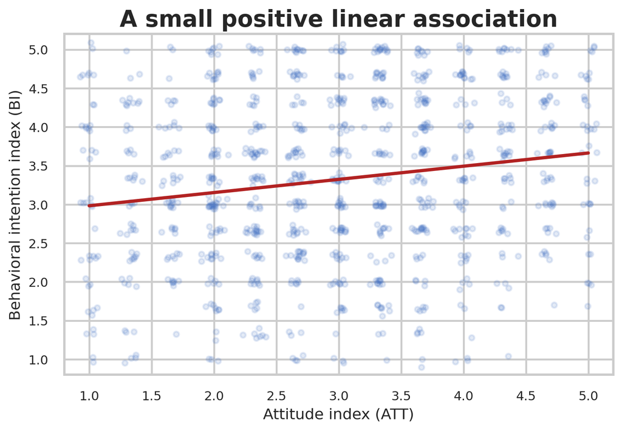

## Slope = expected change in intention

- Slope is rise over run
- Run: ATT increases by 1 point
- Rise: predicted BI changes by $b_1$
- Units: BI points per ATT point

**b₁ = 0.17**: one ATT point corresponds to about 0.17 higher predicted BI.

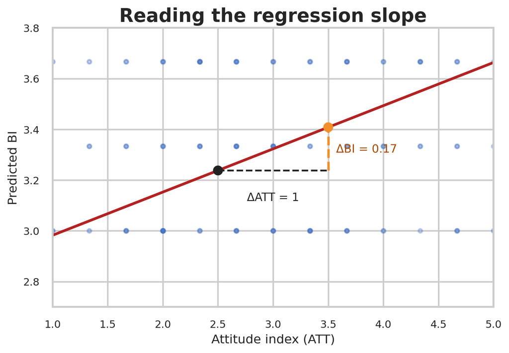

## Residuals are vertical prediction errors

- Residual: observed minus predicted
- Above line: positive residual
- Below line: negative residual
- Least squares minimizes squared residuals

Thirty cases are displayed; the line uses all 1,000 cases.

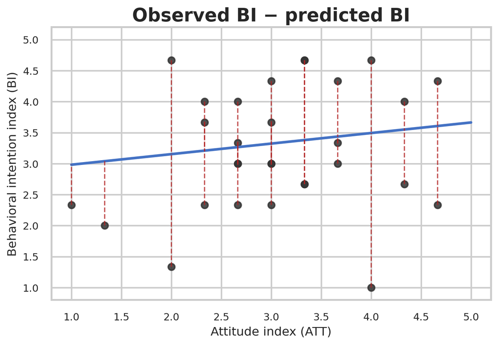

## Regression improves the mean model

- Baseline predicts mean BI for everyone
- Regression lets prediction vary with ATT
- Compare residual sums of squares
- Smaller SSE means better in-sample fit

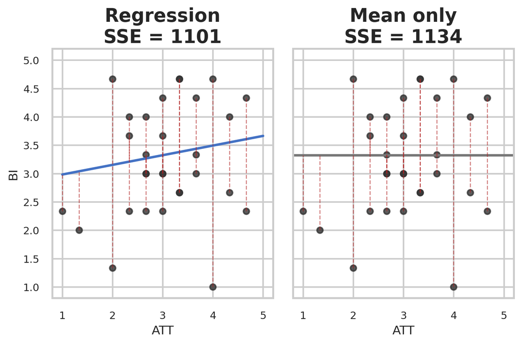

## R² = proportional error reduction

- Total error comes from the mean model
- Residual error remains after regression
- $R^2=1-SSE_{model}/SSE_{mean}$
- ATT explains a small share of BI variance

**R² = 0.029**: about 2.9% of BI variance is associated with ATT.

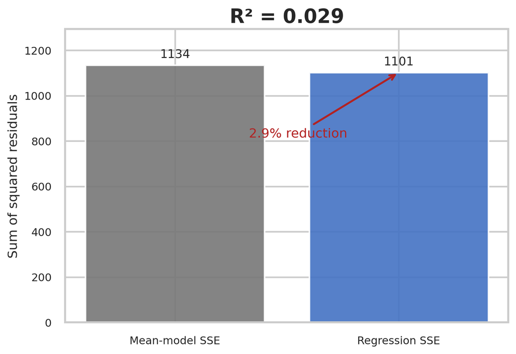

## F tests whether the slope is zero

- Null hypothesis: $b_1=0$
- *F* compares explained and residual variance
- Degrees of freedom: 1 and *N* − 2
- Large samples detect small associations

**F(1, 998) = 29.98, p < .001**. Significance does not imply a large $R^2$.

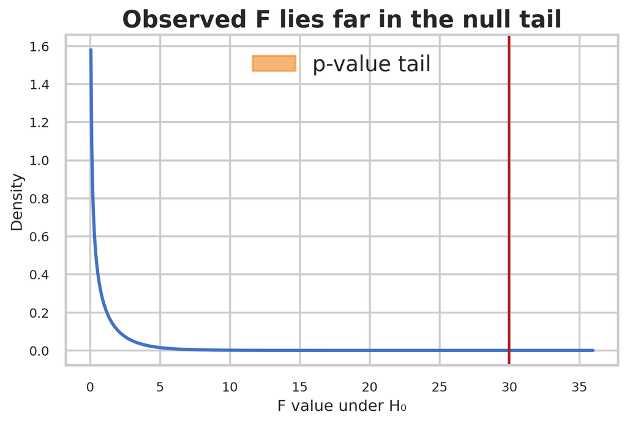

## Predictions reveal model limits

- Compare predicted and observed BI
- Perfect predictions follow the diagonal
- Predictions occupy a narrow range
- ATT alone leaves substantial error

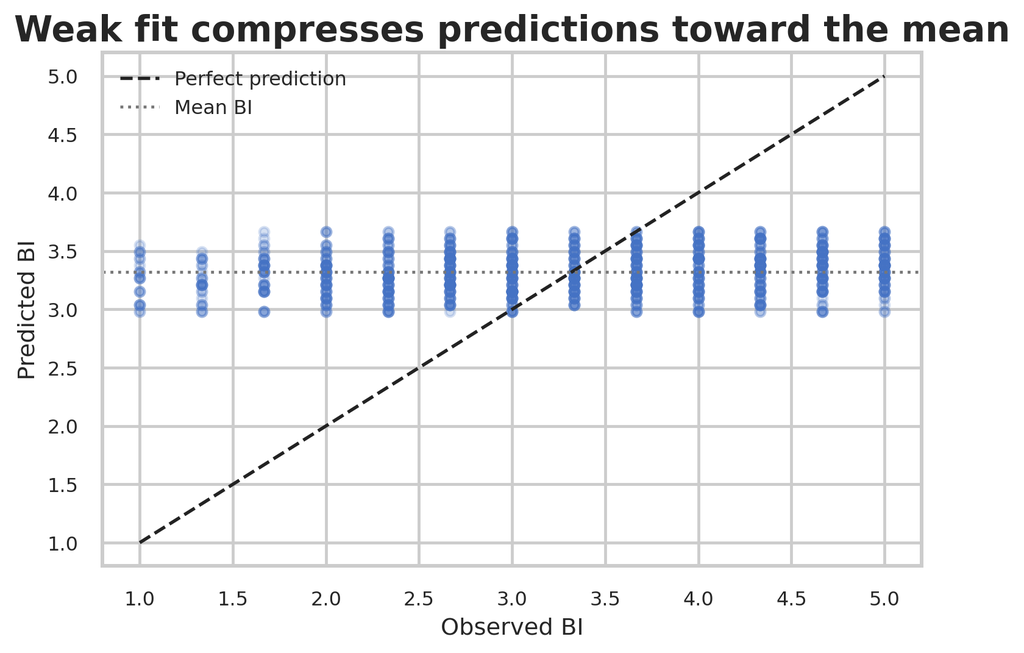

## Grade 6 as a dummy predictor

- Code Grades 4–5 = 0
- Code Grade 6 = 1
- Intercept: mean BI for Grades 4–5
- Slope: Grade 6 minus Grades 4–5

**b₁ = -0.05, p = 0.478**. The dummy coefficient is a mean difference.

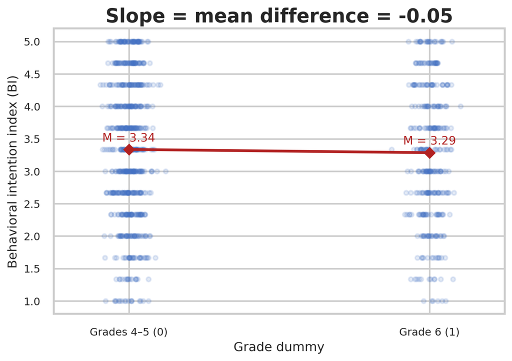

## Two predictors, two linear effects

- One additive model predicts BI
- Bottom axis varies ATT from 1 to 5
- Top axis varies Grade 6 from 0 to 1
- Hold the other predictor at its mean
- Linearity means a constant slope

**Predicted BI = 2.83 + 0.17(ATT) − 0.05(Grade 6)**

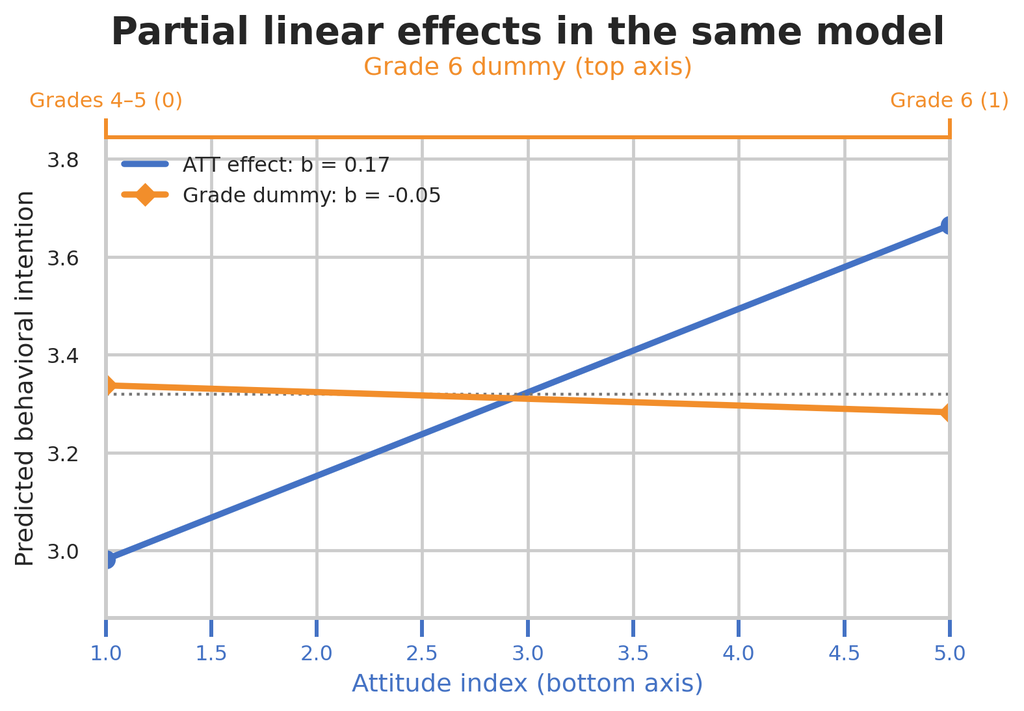

Lab 6.2:  
Simple linear regression

## Lab 6.2: Data analysis scripts

```
* Simple linear regression: DV_INDEX predicted by IV_INDEX1.
REGRESSION
  /DEPENDENT DV_INDEX
  /METHOD=ENTER IV_INDEX1
  /STATISTICS COEFF OUTS R ANOVA CI(95)
  /RESIDUALS HISTOGRAM(ZRESID) NORMPROB(ZRESID).

* Scatterplot with fitted linear regression line.
GGRAPH
  /GRAPHDATASET NAME="graphdataset"
    VARIABLES=IV_INDEX1 DV_INDEX
  /GRAPHSPEC SOURCE=INLINE.
BEGIN GPL
  SOURCE: s=userSource(id("graphdataset"))
  DATA: IV_INDEX1=col(source(s), name("IV_INDEX1"))
  DATA: DV_INDEX=col(source(s), name("DV_INDEX"))
  GUIDE: axis(dim(1), label("IV_INDEX1"))
  GUIDE: axis(dim(2), label("DV_INDEX"))
  GUIDE: text.title(label("Simple Linear Regression: DV_INDEX by IV_INDEX1"))
  ELEMENT: point(position(IV_INDEX1*DV_INDEX))
  ELEMENT: line(position(smooth.linear(IV_INDEX1*DV_INDEX)))
END GPL.
```

```
import numpy as np
import pandas as pd
import matplotlib.pyplot as plt
import statsmodels.api as sm

# Read TSV file from the same directory as the notebook.
df = pd.read_csv("komp014-simulated-data-n100.tsv", sep="\t")

# Simple linear regression: DV_INDEX predicted by IV_INDEX1.
X = sm.add_constant(df["IV_INDEX1"])
y = df["DV_INDEX"]

model = sm.OLS(y, X).fit()

# Full regression output: coefficients, R², F-test, p-values, 95% CIs.
print(model.summary())

# Scatterplot with fitted regression line.
x_grid = np.linspace(df["IV_INDEX1"].min(), df["IV_INDEX1"].max(), 200)
X_grid = sm.add_constant(x_grid)
y_hat = model.predict(X_grid)

plt.figure(figsize=(7, 5))
plt.scatter(df["IV_INDEX1"], df["DV_INDEX"], alpha=0.7)
plt.plot(x_grid, y_hat, linewidth=2)

plt.xlabel("IV_INDEX1")
plt.ylabel("DV_INDEX")
plt.title("Simple Linear Regression: DV_INDEX by IV_INDEX1")
plt.tight_layout()
plt.show()

# Residual histogram.
plt.figure(figsize=(7, 5))
plt.hist(model.resid, bins=12, edgecolor="black")
plt.xlabel("Residual")
plt.ylabel("Frequency")
plt.title("Distribution of Regression Residuals")
plt.tight_layout()
plt.show()

# Normal Q-Q plot of residuals.
sm.qqplot(model.resid, line="45", fit=True)
plt.title("Normal Q-Q Plot of Regression Residuals")
plt.tight_layout()
plt.show()
```

- [prompt for code](https://gemini.google.com/)
- [execute code](https://colab.new/)

## Lecture-Lab 6.3: Multivariate analysis (MRA)

KNHSM08 / KOMP014: Quantitative Methods in  
Music Education Research 2026

nils.holmberg@iko.lu.se

## The article’s empirical question

- Is music teaching implemented on **equal terms**?
- What explains teacher variation?
- How do schools differ?

Synthetic reproduction of Björk et al. (2019). The records reproduce published quantitative patterns; they are not original participants.

| Evidence source | *n* | Main contribution |
| --- | --- | --- |
| Teachers | 133 | Curriculum implementation and predictors |
| Principals / schools | 82 | Resources, support, and activities |
| Open comments | 687 | Context for quantitative patterns |

## Why two grade-level models?

- National goals differ by grade band.
- LP1–2 contains **14 items**.
- LP3–6 contains **16 items**.
- Teachers answered relevant levels.
- Samples overlap; this is **not** a grade experiment.

Two related but separate curriculum instruments

| Scale | Items | n | Mean | SD | α |
| --- | --- | --- | --- | --- | --- |
| LP1–2 | 14 | 84 | 3.14 | 0.66 | 0.92 |
| LP3–6 | 16 | 110 | 3.01 | 0.65 | 0.92 |

## Progression of the analyses

1. **Describe** variation
2. **Locate** difficult goals
3. **Compare** education groups
4. **Adjust** for multiple predictors
5. **Triangulate** with school reports

Each step narrows the explanation of unequal implementation.

| Step | Method | Outcome |
| --- | --- | --- |
| 1 | Histograms, M, SD, range | LP1–2 / LP3–6 |
| 2 | Item summaries | Each curriculum goal |
| 3 | One-way ANOVA | Mean by education group |
| 4 | Multiple regression | Unique adjusted associations |
| 5 | Principal frequencies | Variation between schools |

## H1: implementation varies widely

- Means sit near the midpoint.
- Scores span almost the full scale.
- Both reliabilities: **α ≈ .92**.
- LP3–6 is slightly left-shifted.

Similar averages conceal large teacher differences.

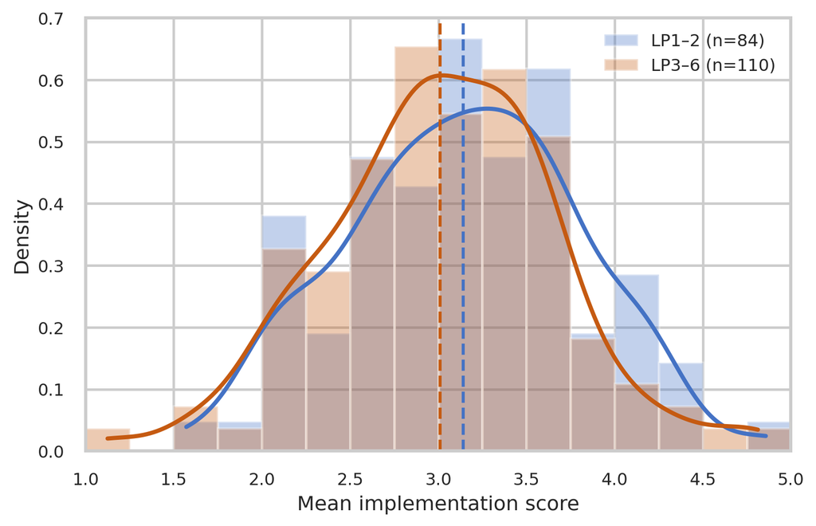

## H1: difficulty depends on the goal

- Group singing ranks highest
- Participatory goals rank high
- Creative goals rank lowest
- Dashed line marks the midpoint

LP1–2: creation and improvisation are the clearest challenge.

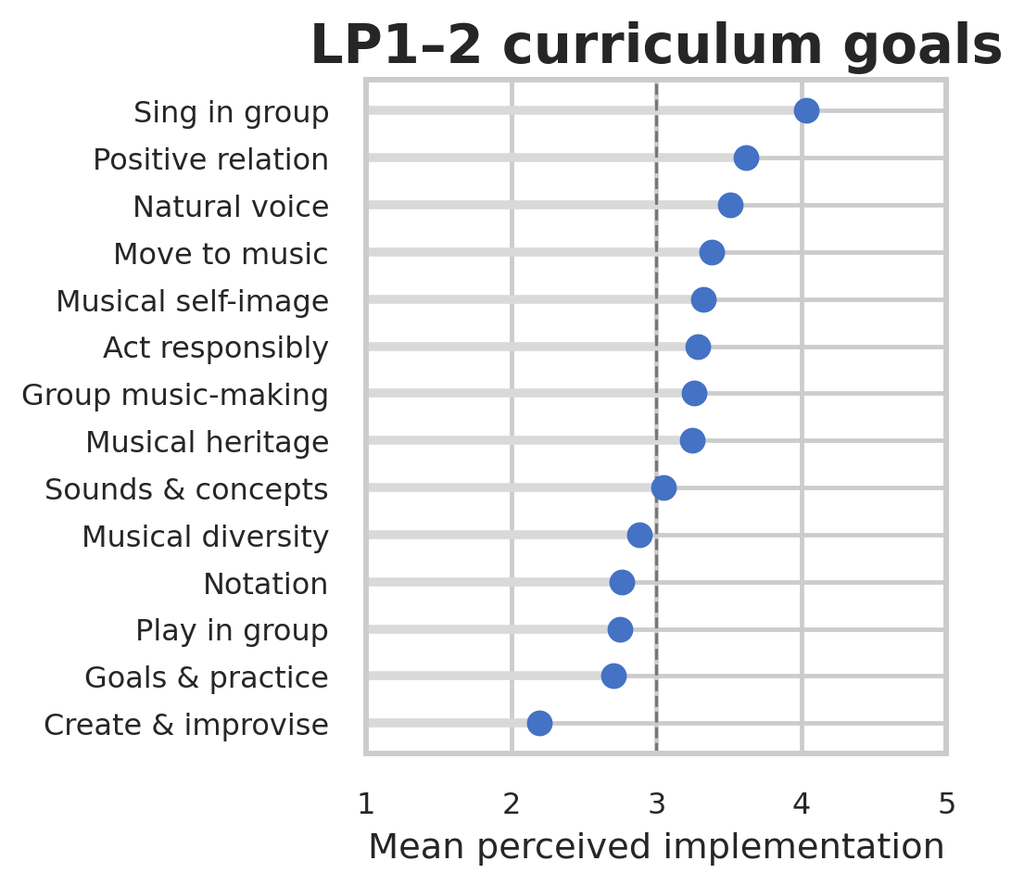

## H1: difficulty depends on the goal

- Group singing ranks highest
- Participatory goals rank high
- Creative goals rank lowest
- Dashed line marks the midpoint

LP3–6: creation—especially with digital tools—is most difficult.

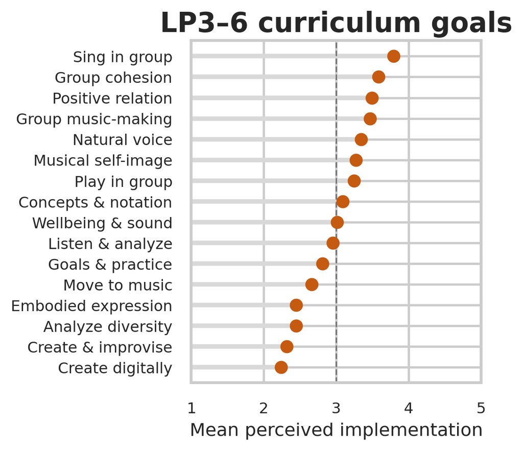

## H2a: first compare formal education

- Factor: four education groups
- Outcome: LP mean score
- LP1–2: not significant
- LP3–6: medium group effect
- Scheffé: subject/dual group drives the contrast

| Scale | F | p | η² |
| --- | --- | --- | --- |
| LP1–2 | 2.49 | 0.066 | 0.085 |
| LP3–6 | 5.14 | 0.002 | 0.127 |

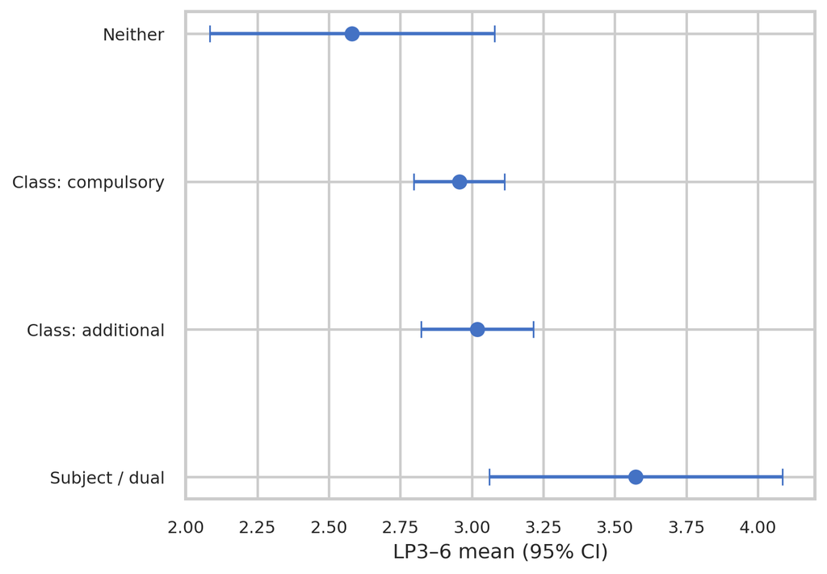

## Why continue from ANOVA to MLR?

- ANOVA asks: **Do groups differ?**
- MLR asks: **What uniquely predicts scores?**
- Predictors overlap.
- Adjustment reallocates shared variance.

A significant group contrast need not remain a unique predictor.

| Feature | One-way ANOVA | Multiple regression |
| --- | --- | --- |
| Main predictor | Formal education | Several teacher/school factors |
| Association | Unadjusted | Adjusted |
| Main test | Omnibus *F* | Model *F* + coefficients |
| Variance | η² | Adjusted *R*² |
| Interpretation | Any group difference? | Unique contribution? |

## H2: adjusted models, specific factors

**LP1–2**

- Singing studies
- Liberal adult education
- Curriculum familiarity
- Resources

**LP3–6**

- Band/ensemble courses
- Curriculum familiarity
- Resources

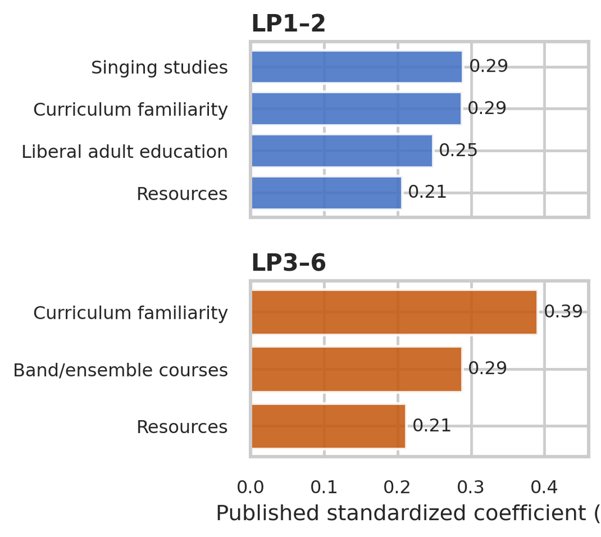

## What changed after adjustment?

- Formal education showed a raw LP3–6 difference.
- It added no significant unique contribution.
- Specific studies were more informative.
- Familiarity and resources survived in both models.

The models explain **33%** of LP1–2 and **35%** of LP3–6 variance.

| Finding | ANOVA | Final MLR |
| --- | --- | --- |
| Formal education | LP3–6 ✓ | — |
| Specific music studies | Not tested | ✓ |
| Curriculum familiarity | Not tested | Both levels ✓ |
| School resources | Not tested | Both levels ✓ |
| Controls overlap | No | Yes |

## H2b–c: familiarity and resources

- **17%** knew the curriculum only partly or hardly at all.
- Resource ratings covered the full scale.
- **35%** disagreed that resources were sufficient.
- Both variables predicted both outcomes.

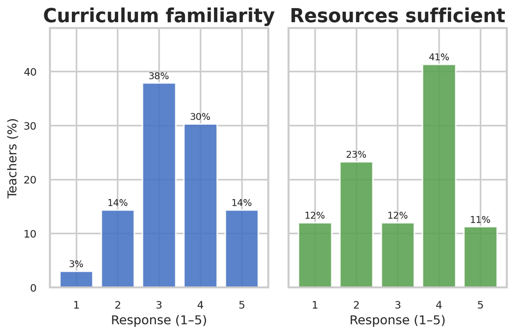

## H3: school opportunities also differ

- 38%: resources insufficient or partly sufficient
- 24%: special music support
- 39%: external partner
- Activities vary sharply

Unequal conditions extend beyond individual teachers.

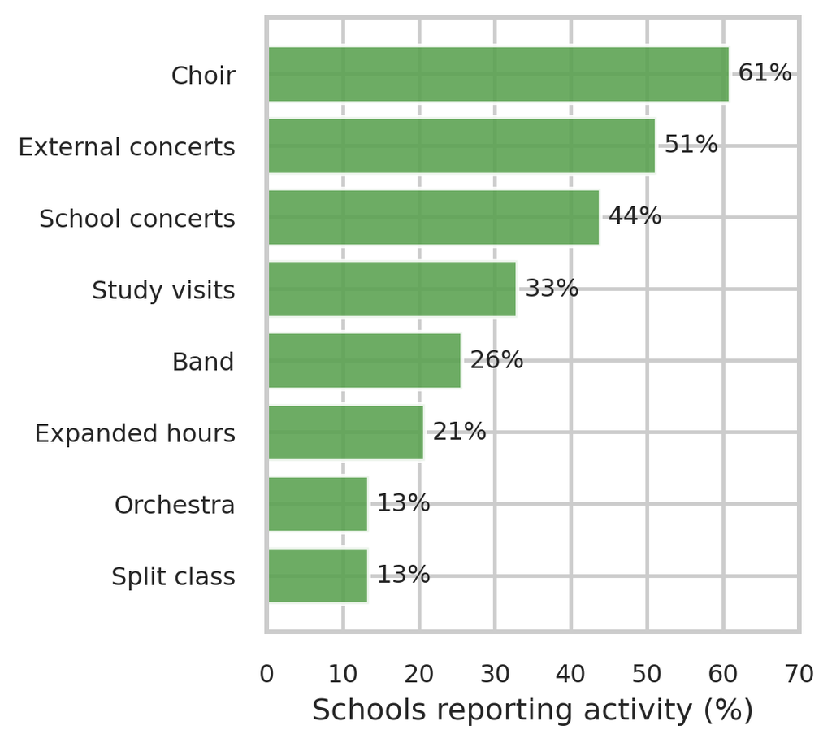

## Reading the results as a sequence

- **H1:** wide variation confirmed
- **H2a:** credentials alone insufficient
- **H2b:** specific engagement matters
- **H2c:** resources matter
- **H3:** schools offer unequal opportunities

| Evidence added | Interpretation gained |
| --- | --- |
| Scale distributions | Inequality exists |
| Item means | Creation is vulnerable |
| Education ANOVA | Some groups differ |
| Adjusted MLR | Specific factors explain more |
| Principal reports | Inequality is organizational too |

The analyses establish associations, not causal effects. Self-reported implementation is not a direct measure of pupils’ learning.

Lab 6.3:  
Multivariate analysis (MRA)

## Lab 6.3: Data analysis scripts

```
* Dummy-code categorical predictor:
* category1 = 0 (reference), category2 = 1.
COMPUTE IV_CAT_GROUP_DUMMY = (IV_CAT_GROUP = "category2").
EXECUTE.

* Multiple linear regression:
* DV_INDEX predicted by IV_INDEX1, IV_INDEX2, and IV_CAT_GROUP.
REGRESSION
  /DEPENDENT DV_INDEX
  /METHOD=ENTER IV_INDEX1 IV_INDEX2 IV_CAT_GROUP_DUMMY
  /STATISTICS COEFF OUTS R ANOVA CI(95)
  /RESIDUALS HISTOGRAM(ZRESID) NORMPROB(ZRESID).
```

```
import pandas as pd
import matplotlib.pyplot as plt
import statsmodels.api as sm
from scipy.stats import zscore

# Read TSV file from the same directory as the notebook.
df = pd.read_csv("komp014-simulated-data-n100.tsv", sep="\t")

# Dummy-code categorical predictor: category1 = 0, category2 = 1.
df["IV_CAT_GROUP_DUMMY"] = (
    df["IV_CAT_GROUP"].map({"category1": 0, "category2": 1})
)

# Standardize DV and all predictors.
df["DV_INDEX_Z"] = zscore(df["DV_INDEX"], ddof=1)
df["IV_INDEX1_Z"] = zscore(df["IV_INDEX1"], ddof=1)
df["IV_INDEX2_Z"] = zscore(df["IV_INDEX2"], ddof=1)
df["IV_CAT_GROUP_Z"] = zscore(df["IV_CAT_GROUP_DUMMY"], ddof=1)

# Multiple linear regression with standardized variables.
X = df[["IV_INDEX1_Z", "IV_INDEX2_Z", "IV_CAT_GROUP_Z"]]
X = sm.add_constant(X)
y = df["DV_INDEX_Z"]

model = sm.OLS(y, X).fit()

# Full regression output.
print(model.summary())

# Standardized beta coefficients and 95% confidence intervals.
betas = model.params.drop("const")
ci = model.conf_int().drop("const")

beta_table = pd.DataFrame({
    "Beta": betas,
    "CI_low": ci[0],
    "CI_high": ci[1]
})

beta_table.index = [
    "IV_INDEX1",
    "IV_INDEX2",
    "IV_CAT_GROUP"
]

print("\nStandardized beta coefficients:")
print(beta_table.round(3))

# Visualization of standardized beta coefficients.
errors = [
    beta_table["Beta"] - beta_table["CI_low"],
    beta_table["CI_high"] - beta_table["Beta"]
]

plt.figure(figsize=(7, 5))
plt.bar(
    beta_table.index,
    beta_table["Beta"],
    yerr=errors,
    capsize=5
)

plt.axhline(0, linewidth=1)
plt.ylabel("Standardized beta coefficient")
plt.xlabel("Predictor")
plt.title("Comparison of Standardized Regression Coefficients")
plt.tight_layout()
plt.show()
```

- [prompt for code](https://gemini.google.com/)
- [execute code](https://colab.new/)

## Lecture-Lab 7.1: Statistical significance and probability

KNHSM08 / KOMP014: Quantitative Methods in  
Music Education Research 2026

nils.holmberg@iko.lu.se

## References

Björk, Cecilia, Marja-Leena Juntunen, Jens Knigge, Bernd Pape, and Lars-Erik Malmberg. 2019. “Musikundervisning Förverkligas På Ojämlika Villkor i Årskurserna 1–6 i Finlands Svenskspråkiga Skolor.” *Finnish Journal of Music Education* 22: 30–58.

Djurfeldt, Göran, and Mimmi Barmark. 2009. *Statistisk Verktygslåda 2: Multivariat Analys*. Studentlitteratur. https://minprodukt2.studentlitteratur.se/dill/#/tematoc/33163_statistisk_verktygslada_2.

Ehninger, Julia, Jens Knigge, Michael Schurig, and Christian Rolle. 2021. “A New Measurement Instrument for Music-Related Argumentative Competence: The MARKO Competency Test and Competency Model.” *Frontiers in Education* 6: 668538. https://doi.org/10.3389/feduc.2021.668538.

Johnson, David. 2021. “Raising Voices: Singing Repertoire and Practices in Swedish Schools.” PhD thesis, Lund University. https://lucris.lub.lu.se/ws/portalfiles/portal/96905350/Raising_Voices.pdf.

Krupp-Schleußner, Valerie, and Andreas Lehmann-Wermser. 2018. “An Instrument for Every Child: A Study on Long-Term Effects of Extended Music Education in German Primary Schools.” *Music Education Research* 20 (1): 44–58. https://doi.org/10.1080/14613808.2016.1249361.

McPherson, Gary E., and Susan A. O’Neill. 2010a. *Student Questionnaire: Motivation to Study Music Compared to Other School Subjects*. Survey instrument, 38 items, 10 pp. https://doi.org/10.1177/1321103X10384202.

McPherson, Gary E., and Susan A. O’Neill. 2010b. “Students’ Motivation to Study Music as Compared to Other School Subjects: A Comparison of Eight Countries.” *Research Studies in Music Education* 32 (2): 101–37. https://doi.org/10.1177/1321103X10384202.

Muijs, Daniel. 2011. *Doing Quantitative Research in Education with SPSS*. 2nd ed. Sage.